# A Bayesian VAR Suite for Forecasting the Australian Economy

Block-exogenous small-open-economy BVARs, pooled density forecasts, 1–12 quarters ahead

Published

June 13, 2026

## 1. What this is

This report documents a suite of Bayesian VARs for forecasting the key Australian macroeconomic aggregates 1–12 quarters ahead, combined into a single pooled **density** forecast. Australia is modelled as a **small open economy**: every VAR member partitions the system into a foreign block (world activity, commodity prices, the foreign policy rate) and a domestic block, and **block exogeneity** forbids domestic variables from feeding back into the foreign block (Cushman & Zha 1997; Zha 1999), at lags and contemporaneously. This is imposed in estimation (not just on impulse responses) and verified numerically (§6).

**Data source for this run:** real. Results are based on final-vintage published data; real-time vintages are not used, so revisions-sensitive comparisons (especially for GDP) should be read with care.

## 2. Data and transformations

The `transform_spec` table is the single source of truth mapping each series to its transform, Minnesota own-lag prior mean (`delta`), block, and steady-state prior anchor (used by the Villani members).

| variable | label | block | transform | delta | ss_mean | ss_sd |
| --- | --- | --- | --- | --- | --- | --- |
| f_act | World activity (US real GDP) | foreign | dlog | 0 | 0.58 | 0.25 |
| f_comm | Commodity prices (RBA ICP, SDR) | foreign | dlog | 0 | 0.00 | 1.00 |
| f_rate | Foreign policy rate (US fed funds) | foreign | level | 1 | 2.50 | 1.00 |
| gdp_growth | Real GDP growth (qtr %) | domestic | dlog | 0 | 0.70 | 0.20 |
| cpi_inflation | Trimmed-mean CPI inflation (qtr %) | domestic | dlog | 0 | 0.62 | 0.15 |
| unemp_rate | Unemployment rate (%) | domestic | level | 1 | 4.50 | 0.75 |
| cash_rate | Cash rate (%) | domestic | level | 1 | 3.50 | 1.00 |
| rtwi | Real TWI (100*log) | domestic | loglevel | 1 | NA | 10.00 |
| tot | Terms of trade (100*log) | domestic | loglevel | 1 | NA | 10.00 |
| wpi_growth | Wage price index growth (qtr %) | domestic | dlog | 0 | 0.80 | 0.20 |
| emp_growth | Employment growth (qtr %) | domestic | dlog | 0 | 0.45 | 0.20 |
| cons_growth | Household consumption growth (qtr %) | domestic | dlog | 0 | 0.70 | 0.20 |
| bond10y | 10y AGS yield (%) | domestic | level | 1 | 4.00 | 1.00 |

Growth-type series enter as 100·Δlog with `delta = 0`; rates and 100·log levels enter with `delta = 1` plus sum-of-coefficients and dummy-initial-observation priors in selected members to discipline the I(1) behaviour at long horizons.

## 3. The suite

Seven block-exogenous VARs spanning prior family (Minnesota vs steady-state), size (8-variable SOE core vs 13-variable medium), tightness (GLP-style marginal-likelihood-selected λ vs fixed tight/loose), lag length (2/4/5) and volatility (constant vs stochastic), plus four univariate anchors (random walk, AR(4), UCSV, unconditional mean). All members are estimated recursively at every forecast origin and produce predictive **draws** for every target variable and horizon, so they pool cleanly.

## 4. Evaluation design

Pseudo-real-time expanding-window evaluation: at each origin *t* every member sees only data through *t* — including the data-driven tightness selection, which is re-run inside each origin. Combination weights at *t* use only scores whose realization was observable at *t* (`s + h ≤ t`). Both properties are enforced structurally and verified by automated tests (§6). Densities are scored with the log score and CRPS (`scoringRules`), points with RMSE, and calibration with PIT histograms, all by horizon, for quarterly and year-ended transforms.

## 4½. The COVID quarters

Three quarters of 2020 are 5–30σ events. Following Lenza & Primiceri (2022), the constant-volatility members scale up the residual covariance in the configured COVID quarters — a free scale factor per quarter, estimated by marginal likelihood *recursively at each forecast origin*, with the excess volatility decaying geometrically afterwards — implemented as GLS row weighting, with the decaying scale path carried into the predictive shocks at COVID-era origins. The SV members instead use t-distributed errors (the Carriero–Clark–Marcellino–Mertens SV-t specification), so the spike is absorbed by the transitory scale mixture rather than the persistent volatility process. The Minnesota σ-calibration and the data-driven tightness selection run on the same weighted data (Hartwig 2024). COVID observations remain in the forecast jump-off — only their likelihood contribution is down-weighted. A `dummy` option (≈ dropping the quarters, Schorfheide–Song 2024) is available for comparison; its known cost is unrealistically tight predictive bands at pandemic-era origins. See DECISIONS.md D17.

Because a handful of extreme realizations dominate mean log scores, the tables below are complemented by `output/tables/scores_by_horizon_excovid.csv`, which excludes the COVID realization quarters from scoring.

## 5. Results

### 5.1 Density accuracy by horizon

Mean CRPS by horizon (lower is better), members vs pooled combinations:

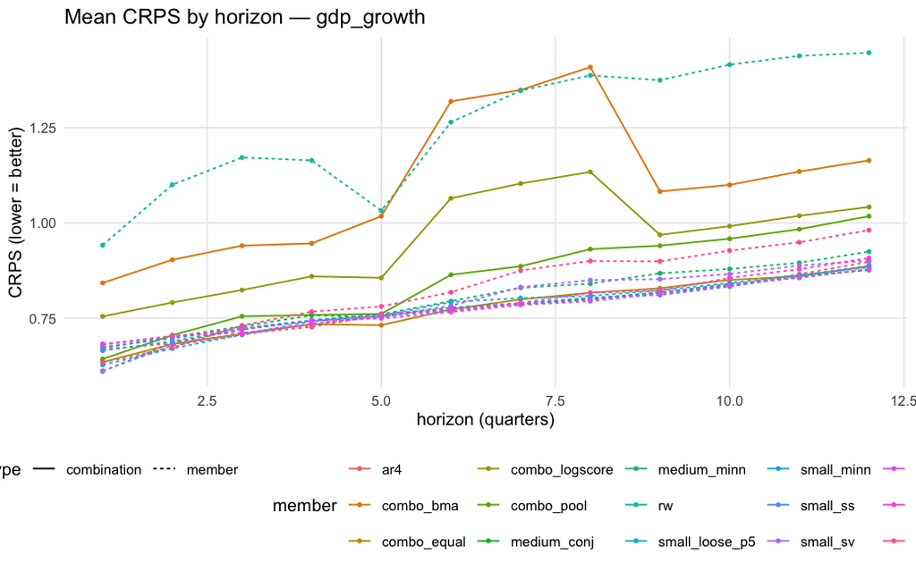

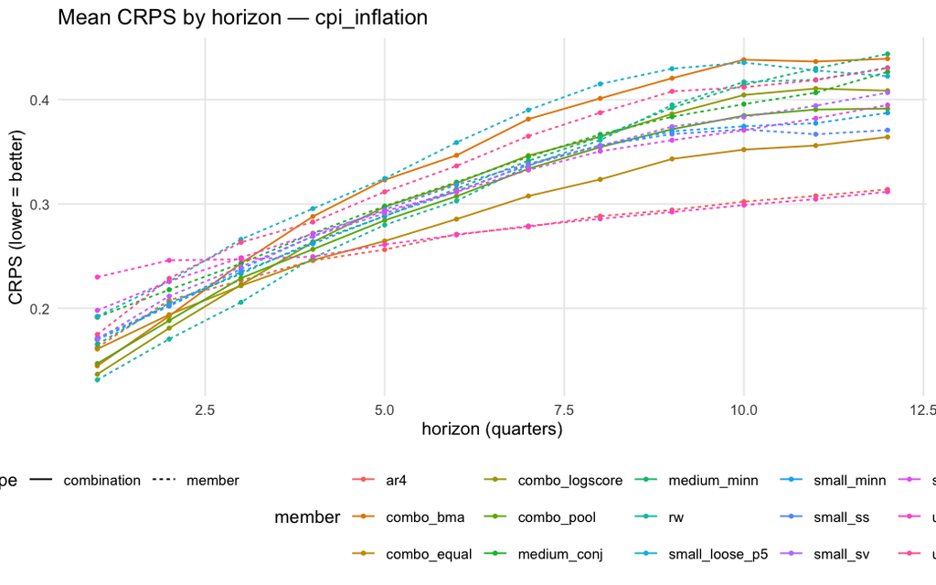

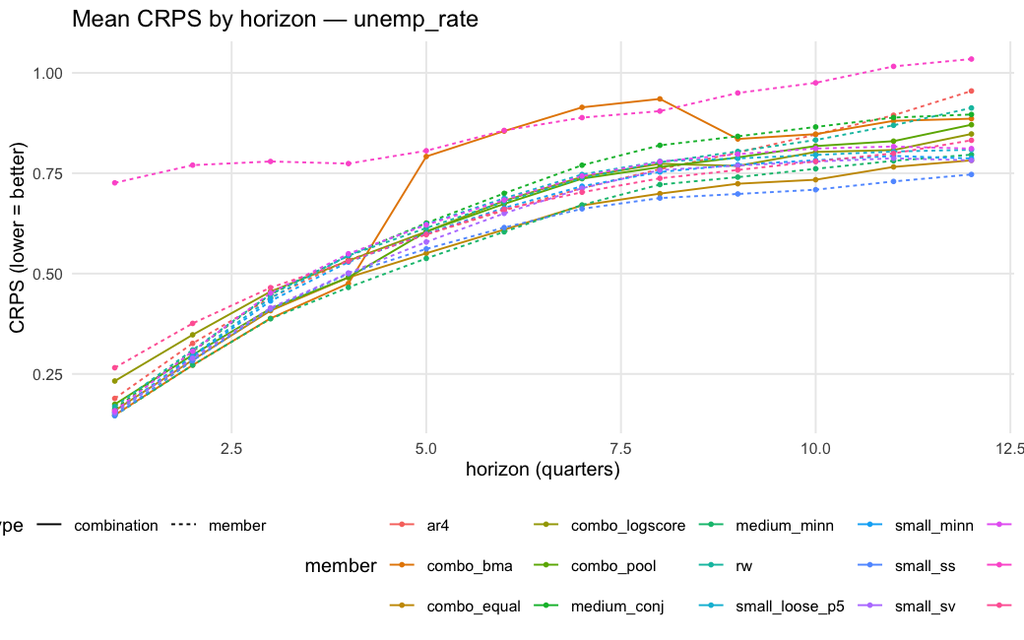

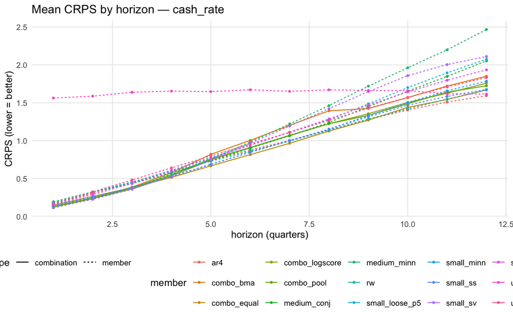

Mean CRPS at h = 1, 4, 8, 12 (quarterly transforms)

|  | member | variable | crps.1 | crps.12 | crps.4 | crps.8 |
| --- | --- | --- | --- | --- | --- | --- |
| 565 | medium_minn | cash_rate | 0.113 | 2.467 | 0.559 | 1.462 |
| 1035 | small_sv | cash_rate | 0.115 | 2.111 | 0.533 | 1.422 |
| 283 | combo_logscore | cash_rate | 0.122 | 1.758 | 0.532 | 1.223 |
| 95 | combo_bma | cash_rate | 0.124 | 1.850 | 0.576 | 1.393 |
| 377 | combo_pool | cash_rate | 0.130 | 1.724 | 0.547 | 1.223 |
| 941 | small_ss | cash_rate | 0.139 | 1.676 | 0.525 | 1.151 |
| 847 | small_minn | cash_rate | 0.145 | 1.785 | 0.527 | 1.152 |
| 189 | combo_equal | cash_rate | 0.147 | 1.668 | 0.514 | 1.126 |
| 1129 | small_tight | cash_rate | 0.157 | 1.935 | 0.598 | 1.286 |
| 753 | small_loose_p5 | cash_rate | 0.162 | 2.076 | 0.609 | 1.276 |
| 1 | ar4 | cash_rate | 0.167 | 1.593 | 0.589 | 1.141 |
| 1317 | ucsv | cash_rate | 0.170 | 1.832 | 0.639 | 1.266 |
| 659 | rw | cash_rate | 0.183 | 1.670 | 0.590 | 1.136 |
| 471 | medium_conj | cash_rate | 0.192 | 2.053 | 0.572 | 1.239 |
| 1223 | ucmean | cash_rate | 1.563 | 1.615 | 1.654 | 1.671 |
| 682 | rw | cpi_inflation | 0.131 | 0.431 | 0.248 | 0.361 |
| 306 | combo_logscore | cpi_inflation | 0.137 | 0.408 | 0.263 | 0.365 |
| 118 | combo_bma | cpi_inflation | 0.145 | 0.439 | 0.288 | 0.401 |
| 400 | combo_pool | cpi_inflation | 0.147 | 0.391 | 0.257 | 0.354 |
| 212 | combo_equal | cpi_inflation | 0.161 | 0.364 | 0.246 | 0.323 |
| 24 | ar4 | cpi_inflation | 0.162 | 0.314 | 0.246 | 0.288 |
| 588 | medium_minn | cpi_inflation | 0.165 | 0.444 | 0.264 | 0.364 |
| 870 | small_minn | cpi_inflation | 0.170 | 0.387 | 0.262 | 0.356 |
| 1058 | small_sv | cpi_inflation | 0.170 | 0.407 | 0.269 | 0.356 |
| 964 | small_ss | cpi_inflation | 0.172 | 0.371 | 0.269 | 0.356 |
| 1340 | ucsv | cpi_inflation | 0.175 | 0.430 | 0.283 | 0.387 |
| 494 | medium_conj | cpi_inflation | 0.191 | 0.426 | 0.272 | 0.367 |
| 776 | small_loose_p5 | cpi_inflation | 0.192 | 0.422 | 0.295 | 0.415 |
| 1152 | small_tight | cpi_inflation | 0.198 | 0.395 | 0.272 | 0.350 |
| 1246 | ucmean | cpi_inflation | 0.230 | 0.312 | 0.250 | 0.286 |
| 623 | medium_minn | gdp_growth | 0.610 | 0.925 | 0.743 | 0.840 |
| 1093 | small_sv | gdp_growth | 0.611 | 0.901 | 0.735 | 0.850 |
| 811 | small_loose_p5 | gdp_growth | 0.627 | 0.883 | 0.741 | 0.808 |
| 1375 | ucsv | gdp_growth | 0.634 | 0.981 | 0.767 | 0.900 |
| 247 | combo_equal | gdp_growth | 0.634 | 0.887 | 0.734 | 0.817 |
| 435 | combo_pool | gdp_growth | 0.642 | 1.018 | 0.758 | 0.931 |
| 999 | small_ss | gdp_growth | 0.664 | 0.888 | 0.743 | 0.804 |
| 59 | ar4 | gdp_growth | 0.668 | 0.898 | 0.727 | 0.797 |
| 529 | medium_conj | gdp_growth | 0.672 | 0.876 | 0.757 | 0.800 |
| 905 | small_minn | gdp_growth | 0.674 | 0.880 | 0.744 | 0.802 |
| 1281 | ucmean | gdp_growth | 0.680 | 0.908 | 0.732 | 0.816 |
| 1187 | small_tight | gdp_growth | 0.682 | 0.878 | 0.743 | 0.794 |
| 341 | combo_logscore | gdp_growth | 0.754 | 1.042 | 0.860 | 1.134 |
| 153 | combo_bma | gdp_growth | 0.842 | 1.164 | 0.946 | 1.409 |
| 717 | rw | gdp_growth | 0.941 | 1.447 | 1.164 | 1.387 |
| 1023 | small_ss | unemp_rate | 0.146 | 0.747 | 0.500 | 0.688 |
| 647 | medium_minn | unemp_rate | 0.146 | 0.796 | 0.466 | 0.722 |
| 177 | combo_bma | unemp_rate | 0.148 | 0.886 | 0.475 | 0.935 |
| 929 | small_minn | unemp_rate | 0.152 | 0.787 | 0.529 | 0.753 |
| 1117 | small_sv | unemp_rate | 0.154 | 0.782 | 0.501 | 0.758 |
| 835 | small_loose_p5 | unemp_rate | 0.155 | 0.808 | 0.546 | 0.780 |
| 1211 | small_tight | unemp_rate | 0.158 | 0.811 | 0.549 | 0.779 |
| 271 | combo_equal | unemp_rate | 0.159 | 0.782 | 0.490 | 0.699 |
| 553 | medium_conj | unemp_rate | 0.163 | 0.896 | 0.545 | 0.820 |
| 741 | rw | unemp_rate | 0.169 | 0.913 | 0.545 | 0.777 |
| 459 | combo_pool | unemp_rate | 0.174 | 0.871 | 0.490 | 0.765 |
| 83 | ar4 | unemp_rate | 0.189 | 0.955 | 0.534 | 0.760 |
| 365 | combo_logscore | unemp_rate | 0.232 | 0.848 | 0.532 | 0.774 |
| 1399 | ucsv | unemp_rate | 0.265 | 0.832 | 0.531 | 0.737 |
| 1305 | ucmean | unemp_rate | 0.726 | 1.034 | 0.774 | 0.905 |

Mean log predictive density at h = 1, 4, 8, 12 (higher = better)

|  | member | variable | logdens.1 | logdens.12 | logdens.4 | logdens.8 |
| --- | --- | --- | --- | --- | --- | --- |
| 283 | combo_logscore | cash_rate | 0.11 | -2.63 | -1.39 | -2.20 |
| 377 | combo_pool | cash_rate | 0.10 | -2.63 | -1.41 | -2.20 |
| 1035 | small_sv | cash_rate | 0.05 | -2.91 | -1.37 | -2.55 |
| 189 | combo_equal | cash_rate | -0.04 | -2.51 | -1.33 | -2.07 |
| 941 | small_ss | cash_rate | -0.07 | -2.63 | -1.32 | -2.20 |
| 847 | small_minn | cash_rate | -0.11 | -2.69 | -1.31 | -2.20 |
| 753 | small_loose_p5 | cash_rate | -0.11 | -2.77 | -1.46 | -2.20 |
| 95 | combo_bma | cash_rate | -0.15 | -2.77 | -1.51 | -2.43 |
| 1129 | small_tight | cash_rate | -0.18 | -3.25 | -1.50 | -2.60 |
| 471 | medium_conj | cash_rate | -0.23 | -3.08 | -1.32 | -2.23 |
| 1 | ar4 | cash_rate | -0.28 | -2.55 | -1.40 | -2.09 |
| 659 | rw | cash_rate | -0.35 | -2.70 | -1.33 | -2.08 |
| 565 | medium_minn | cash_rate | -0.44 | -3.11 | -1.44 | -2.86 |
| 1317 | ucsv | cash_rate | -0.95 | -6.69 | -8.01 | -9.17 |
| 1223 | ucmean | cash_rate | -2.53 | -2.95 | -2.71 | -2.77 |
| 682 | rw | cpi_inflation | 0.06 | -1.18 | -0.49 | -1.04 |
| 306 | combo_logscore | cpi_inflation | 0.03 | -1.51 | -0.68 | -1.41 |
| 400 | combo_pool | cpi_inflation | 0.01 | -1.47 | -0.67 | -1.39 |
| 118 | combo_bma | cpi_inflation | -0.02 | -1.63 | -0.95 | -1.74 |
| 212 | combo_equal | cpi_inflation | -0.05 | -1.32 | -0.47 | -1.07 |
| 24 | ar4 | cpi_inflation | -0.09 | -5.90 | -1.14 | -5.01 |
| 588 | medium_minn | cpi_inflation | -0.12 | -2.22 | -1.43 | -2.22 |
| 1058 | small_sv | cpi_inflation | -0.17 | -2.88 | -2.01 | -1.51 |
| 494 | medium_conj | cpi_inflation | -0.22 | -13.39 | -7.75 | -16.64 |
| 1340 | ucsv | cpi_inflation | -0.25 | -8.45 | -4.98 | -7.23 |
| 964 | small_ss | cpi_inflation | -0.35 | -8.93 | -10.73 | -15.78 |
| 870 | small_minn | cpi_inflation | -0.42 | -10.87 | -10.18 | -15.33 |
| 1246 | ucmean | cpi_inflation | -0.45 | -6.44 | -0.92 | -3.36 |
| 776 | small_loose_p5 | cpi_inflation | -0.47 | -3.87 | -8.74 | -9.68 |
| 1152 | small_tight | cpi_inflation | -0.82 | -13.10 | -13.80 | -18.84 |
| 247 | combo_equal | gdp_growth | -7.35 | -1.81 | -3.07 | -2.17 |
| 341 | combo_logscore | gdp_growth | -7.36 | -2.10 | -3.23 | -2.59 |
| 435 | combo_pool | gdp_growth | -7.40 | -2.03 | -3.24 | -2.33 |
| 153 | combo_bma | gdp_growth | -8.06 | -2.36 | -4.08 | -3.31 |
| 623 | medium_minn | gdp_growth | -12.04 | -7.63 | -13.91 | -24.42 |
| 1375 | ucsv | gdp_growth | -15.07 | -22.54 | -10.55 | -24.71 |
| 1093 | small_sv | gdp_growth | -17.03 | -4.55 | -22.14 | -18.62 |
| 811 | small_loose_p5 | gdp_growth | -17.94 | -26.07 | -24.31 | -24.12 |
| 905 | small_minn | gdp_growth | -18.72 | -Inf | -Inf | -Inf |
| 59 | ar4 | gdp_growth | -Inf | -Inf | -24.93 | -28.99 |
| 529 | medium_conj | gdp_growth | -Inf | -35.26 | -Inf | -Inf |
| 717 | rw | gdp_growth | -Inf | -2.53 | -5.10 | -3.09 |
| 999 | small_ss | gdp_growth | -Inf | -35.56 | -Inf | -Inf |
| 1187 | small_tight | gdp_growth | -Inf | -32.10 | -25.23 | -Inf |
| 1281 | ucmean | gdp_growth | -Inf | -Inf | -Inf | -Inf |
| 647 | medium_minn | unemp_rate | 0.09 | -1.76 | -1.43 | -1.64 |
| 271 | combo_equal | unemp_rate | 0.03 | -1.85 | -1.23 | -1.71 |
| 177 | combo_bma | unemp_rate | 0.01 | -2.01 | -1.40 | -2.04 |
| 459 | combo_pool | unemp_rate | -0.06 | -1.97 | -1.36 | -1.90 |
| 365 | combo_logscore | unemp_rate | -0.13 | -1.93 | -1.30 | -1.85 |
| 1117 | small_sv | unemp_rate | -1.26 | -1.78 | -1.36 | -1.77 |
| 1305 | ucmean | unemp_rate | -1.57 | -2.26 | -1.61 | -1.93 |
| 83 | ar4 | unemp_rate | -3.48 | -5.39 | -3.70 | -5.61 |
| 1211 | small_tight | unemp_rate | -4.83 | -2.02 | -3.37 | -3.15 |
| 1023 | small_ss | unemp_rate | -4.84 | -2.10 | -2.16 | -3.61 |
| 741 | rw | unemp_rate | -4.97 | -4.36 | -4.99 | -5.61 |
| 1399 | ucsv | unemp_rate | -5.34 | -1.93 | -2.42 | -1.85 |
| 553 | medium_conj | unemp_rate | -5.69 | -2.10 | -1.87 | -2.46 |
| 929 | small_minn | unemp_rate | -7.05 | -1.88 | -2.84 | -2.82 |
| 835 | small_loose_p5 | unemp_rate | -7.59 | -1.78 | -2.00 | -2.10 |

### 5.2 Significance

Diebold–Mariano tests (Harvey-corrected, Newey–West lag h−1) against the AR(4) and random-walk benchmarks; stars on CRPS differentials (`***` 1%, `**` 5%, `*` 10%).

DM tests: combinations vs univariate benchmarks

| member | reference | variable | h | dm_crps | p_crps | sig_crps |
| --- | --- | --- | --- | --- | --- | --- |
| combo_equal | ar4 | cash_rate | 1 | -1.543 | 0.132 |  |
| combo_logscore | ar4 | cash_rate | 1 | -2.265 | 0.030 | ** |
| combo_pool | ar4 | cash_rate | 1 | -1.932 | 0.062 | * |
| combo_bma | ar4 | cash_rate | 1 | -1.794 | 0.081 | * |
| combo_equal | rw | cash_rate | 1 | -1.933 | 0.061 | * |
| combo_logscore | rw | cash_rate | 1 | -2.524 | 0.016 | ** |
| combo_pool | rw | cash_rate | 1 | -2.380 | 0.023 | ** |
| combo_bma | rw | cash_rate | 1 | -2.151 | 0.038 | ** |
| combo_equal | ar4 | cash_rate | 4 | -2.179 | 0.037 | ** |
| combo_logscore | ar4 | cash_rate | 4 | -0.790 | 0.435 |  |
| combo_pool | ar4 | cash_rate | 4 | -0.607 | 0.548 |  |
| combo_bma | ar4 | cash_rate | 4 | -0.143 | 0.887 |  |
| combo_equal | rw | cash_rate | 4 | -0.818 | 0.419 |  |
| combo_logscore | rw | cash_rate | 4 | -0.567 | 0.574 |  |
| combo_pool | rw | cash_rate | 4 | -0.500 | 0.621 |  |
| combo_bma | rw | cash_rate | 4 | -0.126 | 0.900 |  |
| combo_equal | ar4 | cash_rate | 8 | -0.120 | 0.905 |  |
| combo_logscore | ar4 | cash_rate | 8 | 0.362 | 0.720 |  |
| combo_pool | ar4 | cash_rate | 8 | 0.353 | 0.727 |  |
| combo_bma | ar4 | cash_rate | 8 | 0.740 | 0.465 |  |
| combo_equal | rw | cash_rate | 8 | -0.052 | 0.959 |  |
| combo_logscore | rw | cash_rate | 8 | 1.069 | 0.294 |  |
| combo_pool | rw | cash_rate | 8 | 1.002 | 0.325 |  |
| combo_bma | rw | cash_rate | 8 | 1.967 | 0.059 | * |
| combo_equal | ar4 | cpi_inflation | 1 | -0.136 | 0.893 |  |
| combo_logscore | ar4 | cpi_inflation | 1 | -1.338 | 0.189 |  |
| combo_pool | ar4 | cpi_inflation | 1 | -0.971 | 0.338 |  |
| combo_bma | ar4 | cpi_inflation | 1 | -0.788 | 0.436 |  |
| combo_equal | rw | cpi_inflation | 1 | 1.223 | 0.229 |  |
| combo_logscore | rw | cpi_inflation | 1 | 0.400 | 0.692 |  |

[output cut: 66 more lines]

### 5.3 Which models earn weight where

Final-origin combination weights (optimal pool, shrunk toward equal), by variable and horizon bucket:

Optimal-pool weights averaged over target variables

| member | far | medium | near |
| --- | --- | --- | --- |
| small_sv | 0.027 | 0.037 | 0.235 |
| medium_minn | 0.118 | 0.124 | 0.160 |
| rw | 0.194 | 0.216 | 0.122 |
| small_minn | 0.027 | 0.027 | 0.101 |
| small_tight | 0.108 | 0.164 | 0.074 |
| small_ss | 0.095 | 0.089 | 0.068 |
| small_loose_p5 | 0.044 | 0.027 | 0.063 |
| medium_conj | 0.091 | 0.094 | 0.057 |
| ar4 | 0.052 | 0.100 | 0.055 |
| ucmean | 0.217 | 0.091 | 0.037 |
| ucsv | 0.027 | 0.031 | 0.027 |

The BMA diagnostic (predictive-likelihood weights, no shrinkage) shows which single member the data favour — by construction it concentrates and is **not** the recommended combination:

BMA diagnostic weights (averaged over variables/buckets)

| member | weight |
| --- | --- |
| ar4 | 0.073 |
| medium_conj | 0.011 |
| medium_minn | 0.330 |
| rw | 0.385 |
| small_loose_p5 | 0.002 |
| small_minn | 0.011 |
| small_ss | 0.019 |
| small_sv | 0.168 |
| small_tight | 0.000 |
| ucmean | 0.000 |
| ucsv | 0.001 |

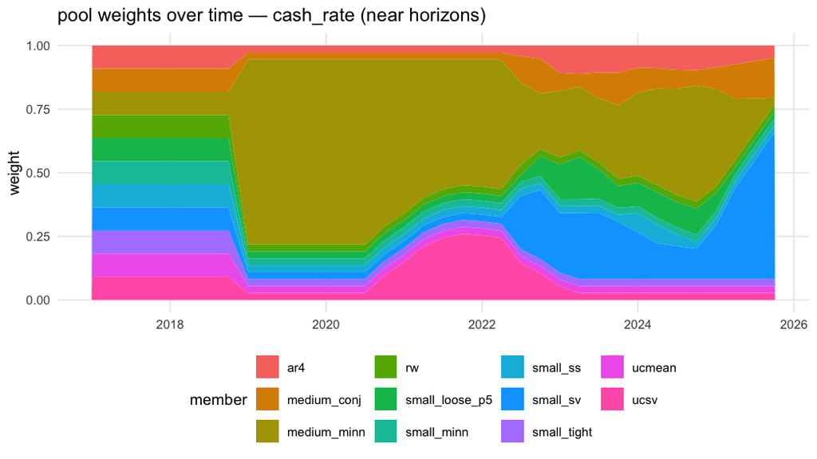

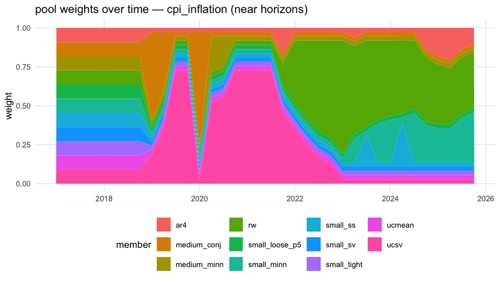

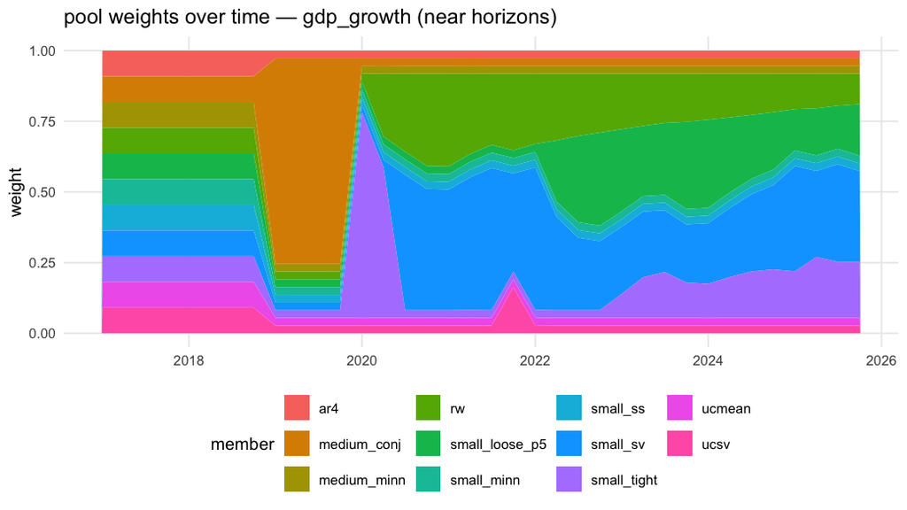

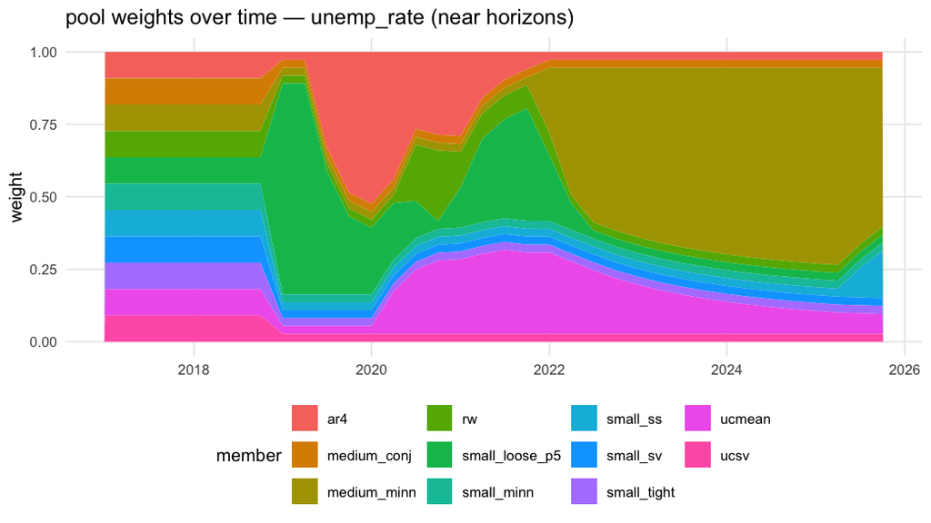

### 5.4 Calibration

PIT histograms by member (h = 1 and h = 4): a calibrated density forecast has uniform PITs. Hump-shaped histograms indicate over-dispersion, U-shapes under-dispersion.

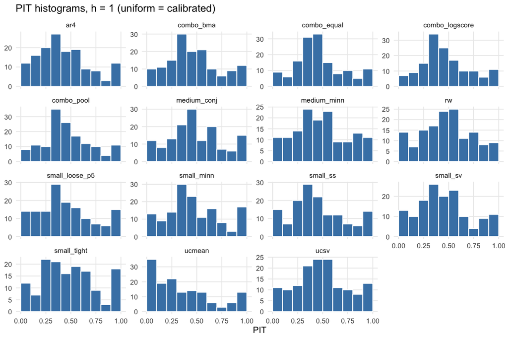

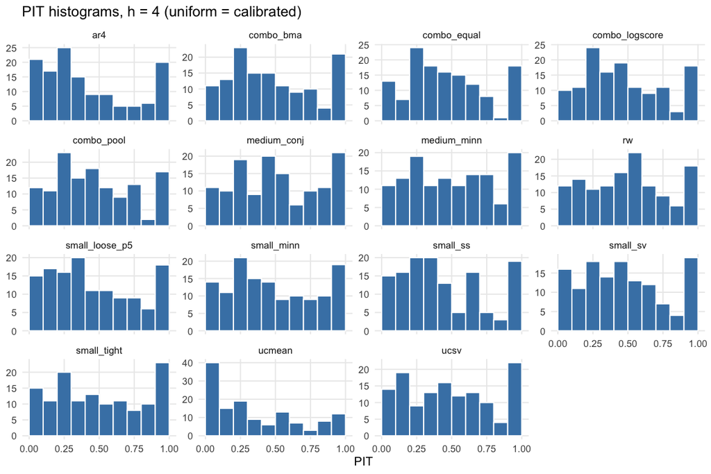

### 5.5 Current forecasts

Fan charts from the optimal-pool combination at the final origin:

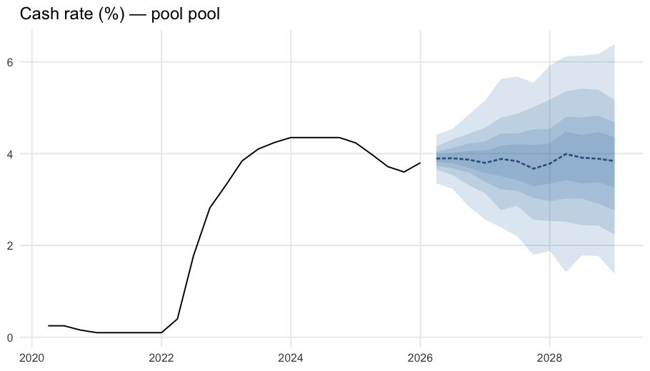

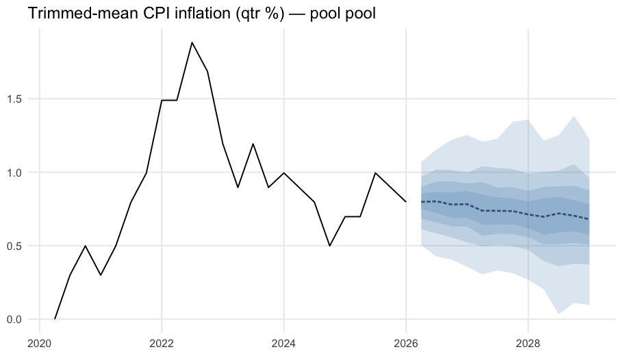

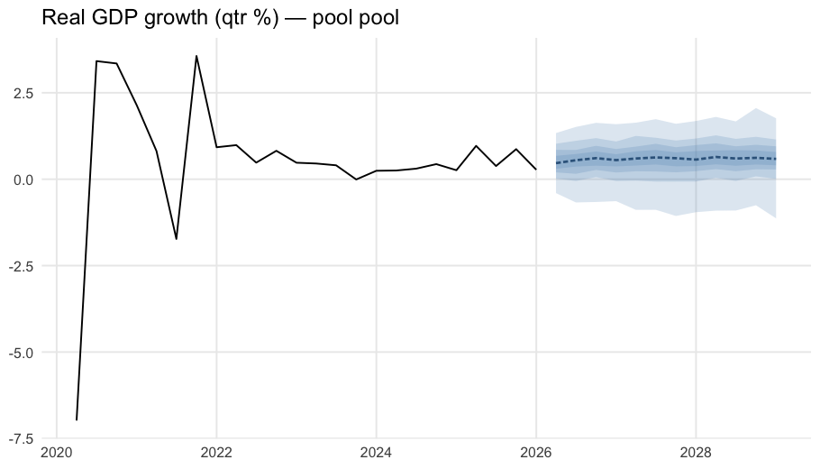

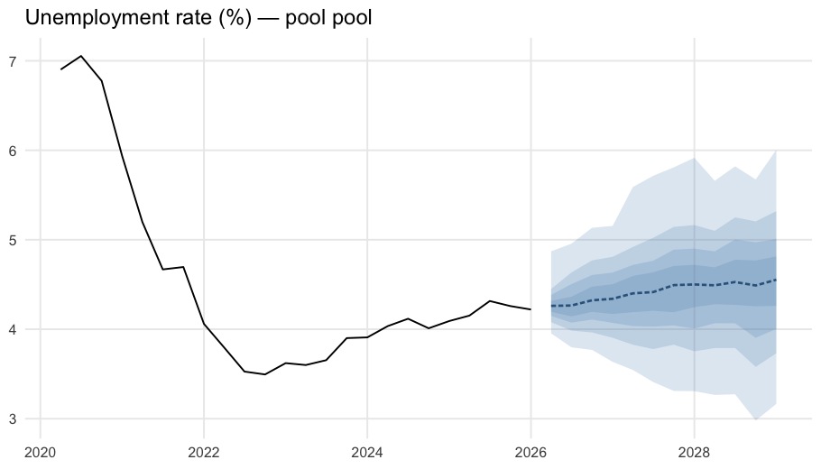

Combined (optimal pool) forecasts: median and 90% interval

| variable | h | point | lo90 | hi90 |
| --- | --- | --- | --- | --- |
| gdp_growth | 1 | 0.46 | -0.40 | 1.34 |
| gdp_growth | 2 | 0.55 | -0.67 | 1.51 |
| gdp_growth | 4 | 0.55 | -0.64 | 1.59 |
| gdp_growth | 8 | 0.57 | -0.95 | 1.68 |
| gdp_growth | 12 | 0.59 | -1.13 | 1.76 |
| cpi_inflation | 1 | 0.80 | 0.50 | 1.07 |
| cpi_inflation | 2 | 0.80 | 0.43 | 1.15 |
| cpi_inflation | 4 | 0.78 | 0.36 | 1.25 |
| cpi_inflation | 8 | 0.71 | 0.27 | 1.36 |
| cpi_inflation | 12 | 0.68 | 0.10 | 1.23 |
| unemp_rate | 1 | 4.26 | 3.95 | 4.87 |
| unemp_rate | 2 | 4.27 | 3.80 | 4.96 |
| unemp_rate | 4 | 4.34 | 3.64 | 5.15 |
| unemp_rate | 8 | 4.50 | 3.31 | 5.92 |
| unemp_rate | 12 | 4.55 | 3.17 | 6.01 |
| cash_rate | 1 | 3.89 | 3.35 | 4.42 |
| cash_rate | 2 | 3.90 | 3.23 | 4.54 |
| cash_rate | 4 | 3.80 | 2.56 | 5.16 |
| cash_rate | 8 | 3.78 | 1.88 | 5.92 |
| cash_rate | 12 | 3.84 | 1.38 | 6.38 |

## 6. Diagnostics

Section-9 self-checks, enforced as a hard gate in the pipeline:

| member | ess_min | stable_share_min | block_exog_max | converged_all | sanity_all | no_lookahead | reproducible |
| --- | --- | --- | --- | --- | --- | --- | --- |
| small_minn | 637.5591 | 0.9733 | 0 | TRUE | TRUE | TRUE | TRUE |
| small_ss | 698.6404 | 0.9867 | 0 | TRUE | TRUE | TRUE | TRUE |
| small_sv | 63.5341 | 1.0000 | 0 | TRUE | TRUE | TRUE | TRUE |
| small_loose_p5 | 753.1893 | 0.8633 | 0 | TRUE | TRUE | TRUE | TRUE |
| medium_minn | 113.6042 | 1.0000 | 0 | TRUE | TRUE | TRUE | TRUE |
| medium_conj | 1000.0000 | 1.0000 | 0 | TRUE | TRUE | TRUE | TRUE |
| small_tight | 1000.0000 | 1.0000 | 0 | TRUE | TRUE | TRUE | TRUE |
| rw | Inf | 1.0000 | 0 | TRUE | TRUE | TRUE | TRUE |
| ar4 | Inf | 1.0000 | 0 | TRUE | TRUE | TRUE | TRUE |
| ucsv | 16.0202 | 1.0000 | 0 | TRUE | TRUE | TRUE | TRUE |
| ucmean | Inf | 1.0000 | 0 | TRUE | TRUE | TRUE | TRUE |

- **Block exogeneity binds:** max |posterior-mean coefficient of a domestic lag inside a foreign equation| across all members and origins is 1.3e-05 (engines with structural zeros report exactly 0).
- **No look-ahead:** corrupting all post-origin data leaves every forecast draw bit-identical.
- **Reproducibility:** re-running an origin with the same master seed gives identical draws.

## 7. Honest limitations

- **Final-vintage data.** The evaluation is pseudo-real-time on (for real runs) final data; genuine real-time vintages would change GDP-related rankings.
- **Combination gains are modest by design.** Equal weights are hard to beat (the combination puzzle); the payoff we target is *calibration and robustness*, not large point-forecast gains, and the tables should be read that way — where a single member beats the pools at a given horizon, the honest summary is that the pool buys insurance, not accuracy.
- **Conditional forecasts** use hard substitution, not Waggoner–Zha shock redistribution; they are a convenience hook, not a policy-scenario tool.
- **The synthetic DGP** is block-exogenous and Gaussian-with-outliers; it validates machinery (recovery of the block structure, calibration under a known truth), not Australian dynamics.